# Continuous-Time Movement Modeling

Which method fits the model best as suggested by the AICc? What do our plots show us about whether OU or OUF best fits the movement data?

```r
# We don't need to fit again. Already fitted OUF previously.
FIT_B <- ctmm.fit(coy2, CTMM = coy2_GUESS, method = "pHREML", control = list(method="pNewton",cores=2), trace = TRUE)
```

```
## Maximizing likelihood.
```

```
## Calculating Hessian.
```

```
## Calculating REML gradient.
```

```
## Calculating REML Hessian.
```

```r
summary(FIT_B)
```

```
## $name
## [1] "OUF anisotropic"
##
## $DOF
##       mean       area      speed
##   12.36822   21.59570 4280.15536
##
## $CI
##                                low      est      high
## area (square kilometers) 23.791745 38.14931 55.841886
## t[position] (hours)       9.070853 15.76743 27.407764
## t[velocity] (minutes)     3.471854  3.66519  3.869292
## speed (kilometers/day)   48.562336 49.30089 50.039283
```

```r
# Is the same as:
summary(M.OUF2)
```

```
## $name
## [1] "OUF anisotropic"
##
## $DOF
##       mean       area      speed
##   12.36822   21.59568 4280.15536
##
## $CI
##                                low      est      high
## area (square kilometers) 23.791746 38.14932 55.841908
## t[position] (hours)       9.070853 15.76743 27.407779
## t[velocity] (minutes)     3.471854  3.66519  3.869292
## speed (kilometers/day)   48.562336 49.30089 50.039283
```

**Step 5: Autocorrelated Kernel Density Estimate Calculation**

After confirming our fitted continuous-time movement model, we use this as the input for the AKDE. We use the AKDE estimator to produce ecologically relevant metrics, such as home range size, range overlap, and occurrence distributions. It is essential to select the best fitting movement model to produce accurate AKDE metric estimates. Plotting the AKDE estimate defaults to show the 95% home range contour and corresponding 95% confidence intervals. The summary produces point estimates and confidence intervals. Other confidence intervals can be specified if desired.

lets just try to run both at the same time again !!! cries !!!

*FS* - *REJOICE! With both models done, we don’t have to do both again. We can just combine them in a list!*

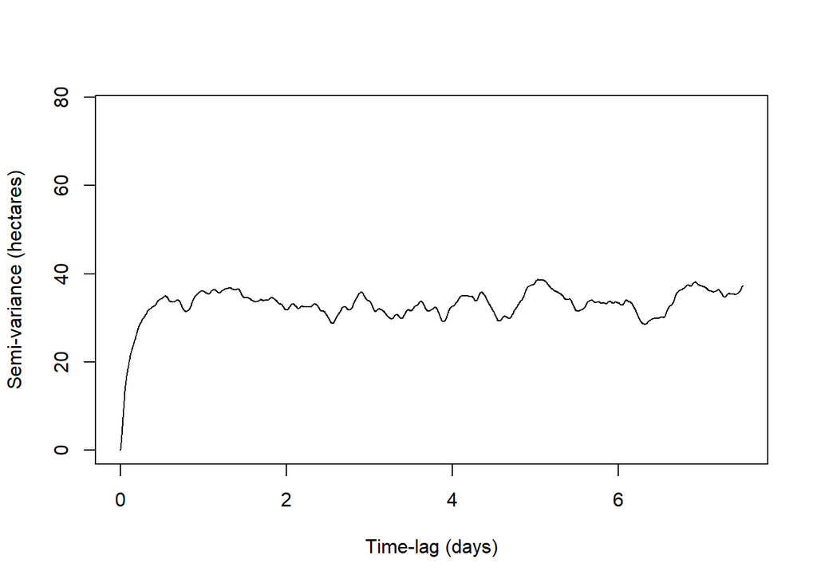

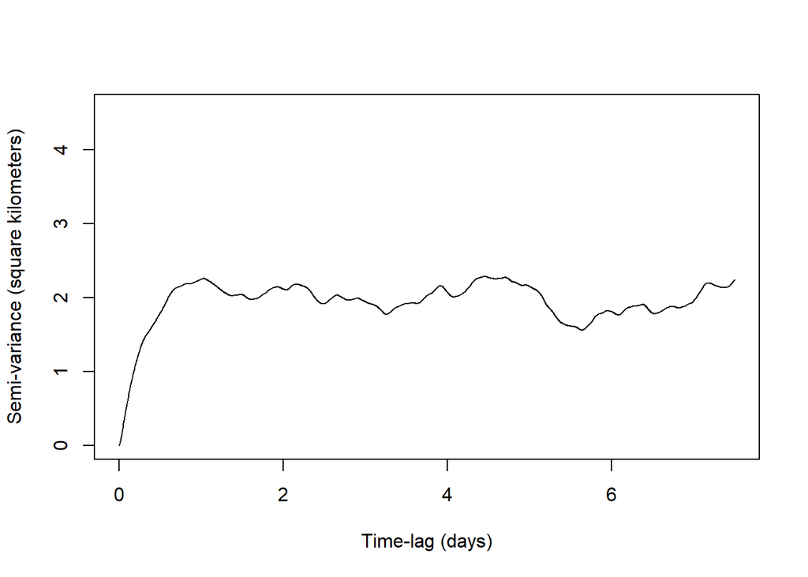

```r
both.coyotes <- coyotes[c("coyG","coyH")]

#variograms

variograms <- list(vg.coy1, vg.coy2)
plot.vg <- lapply(1:2, function(i) plot(variograms[[i]],fraction = 0.5))
```

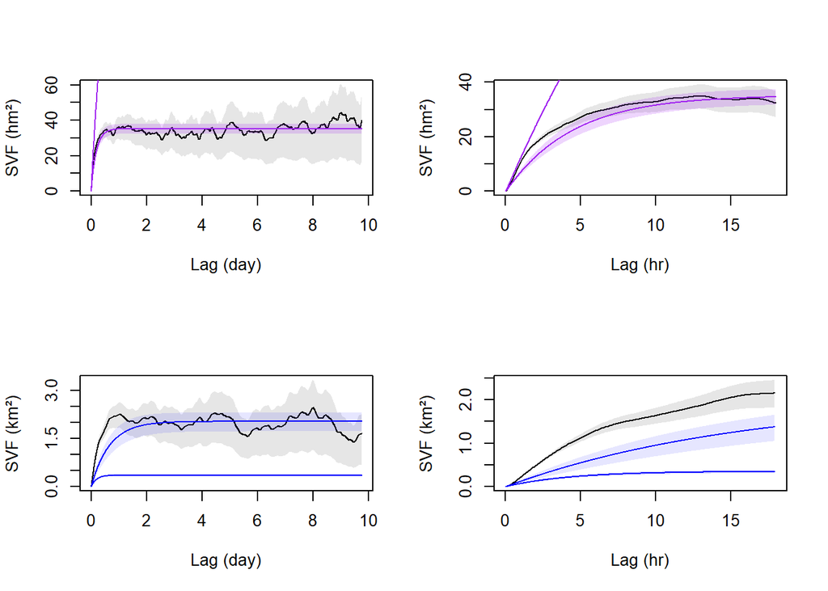

```r
GUESS_2 <- list(guess.fitted.mods, coy2_GUESS)
FITS_2 <- list(FIT_A, M.OUF2)

par(mfrow = c(2, 2))
plot(variograms[[1]],CTMM=FITS_2,col.CTMM=c("purple"),fraction=0.65,level=0.5)
plot(variograms[[1]],CTMM=FITS_2,col.CTMM=c("purple"),fraction=0.05,level=0.5)
plot(variograms[[2]],CTMM=FITS_2,col.CTMM=c("blue"),fraction=0.65,level=0.5)
plot(variograms[[2]],CTMM=FITS_2,col.CTMM=c("blue"),fraction=0.05,level=0.5)
```

```r
names(FITS_2) <- names(both.coyotes[1:2])
```

AKDE corrects for biases due to autocorrelation, small effective sample size, and irregular sampling in time

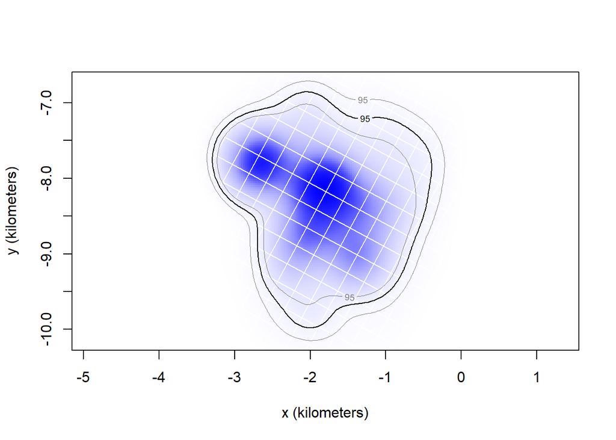

```r
UDS_coyotes <- akde(both.coyotes[1:2],FITS_2)
plot(UDS_coyotes[[1]])
```

```r
summary(UDS_coyotes[[1]])
```

```
## $DOF
##      area bandwidth
##  77.25247 199.63498
##
## $CI
##                               low      est     high
## area (square kilometers) 4.823147 6.109051 7.544616
```

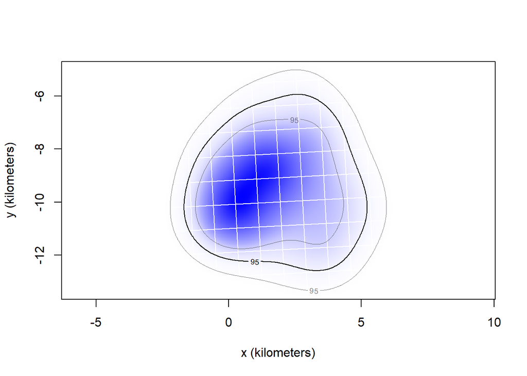

```r
plot(UDS_coyotes[[2]])
```

```r
summary(UDS_coyotes[[2]])
```

```
## $DOF
##      area bandwidth
##  21.59568  36.11144
##
## $CI
##                               low      est     high
## area (square kilometers) 21.91202 35.13525 51.42999
```

This function calculates a useful measure of similarity between distributions evaluate overlap of 95% Home Range.The choice method=“BA” computes the Bhattacharyya’s affinity (BA). Values range from zero (no overlap) to 1 (identical Utilization Distributions).

95% level of confidence

```r
overlap(UDS_coyotes)
```

```
## , , low
##
##           coyG      coyH
## coyG 1.0000000 0.0670412
## coyH 0.0670412 1.0000000
##
## , , est
##
##         coyG    coyH
## coyG 1.00000 0.15641
## coyH 0.15641 1.00000
##
## , , high
##
##           coyG      coyH
## coyG 1.0000000 0.3116938
## coyH 0.3116938 1.0000000
```

plotting overlap

```
## DOP values missing. Assuming DOP=1.
## DOP values missing. Assuming DOP=1.
```

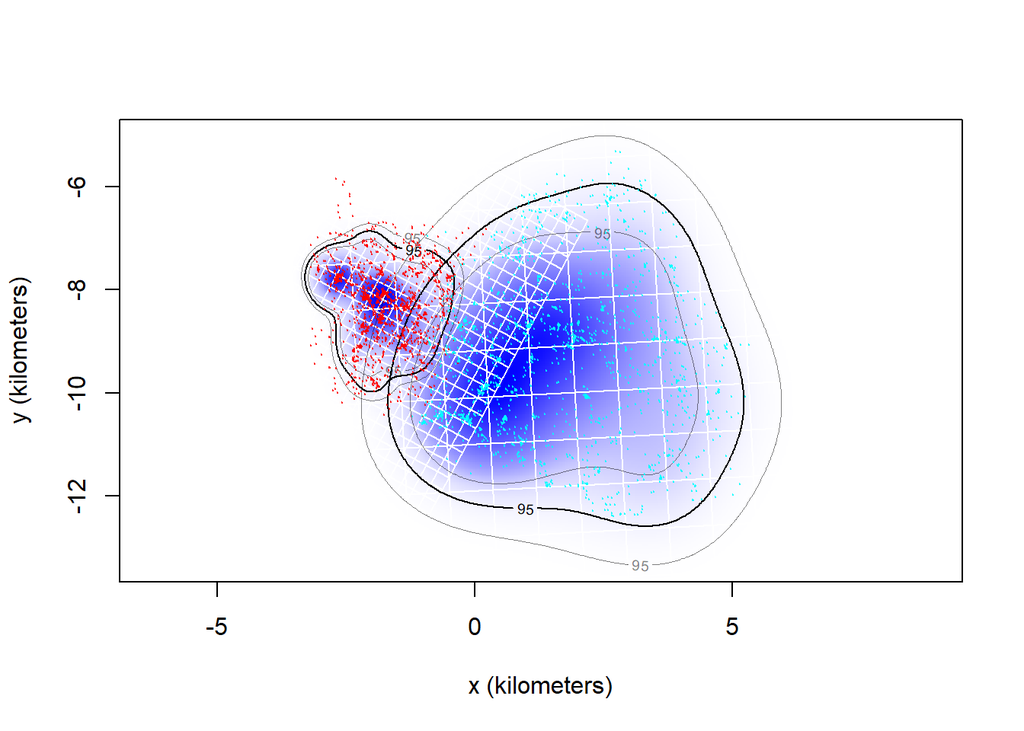

```r
#use the plot function to look at the AKDE UD
#95% Home Range (95% is the default)
#The middle contour represent the maximum likelihood area where the animal spends 95% of its time.
plot(both.coyotes, UD = UDS_coyotes, col=rainbow(length(both.coyotes)))
```

We can also estimate the CDE (conditional distribution of encounters) (Noonan et al., 2020). CDE is a concept describing the long-term encounter location probabilities for movement within home ranges.

```r
CDE_coyotes <- encounter(UDS_coyotes)
CDE_coyotes
```

[output not shown]

[output cut: 26427 more lines]

```
## DOP values missing. Assuming DOP=1.
## DOP values missing. Assuming DOP=1.
```

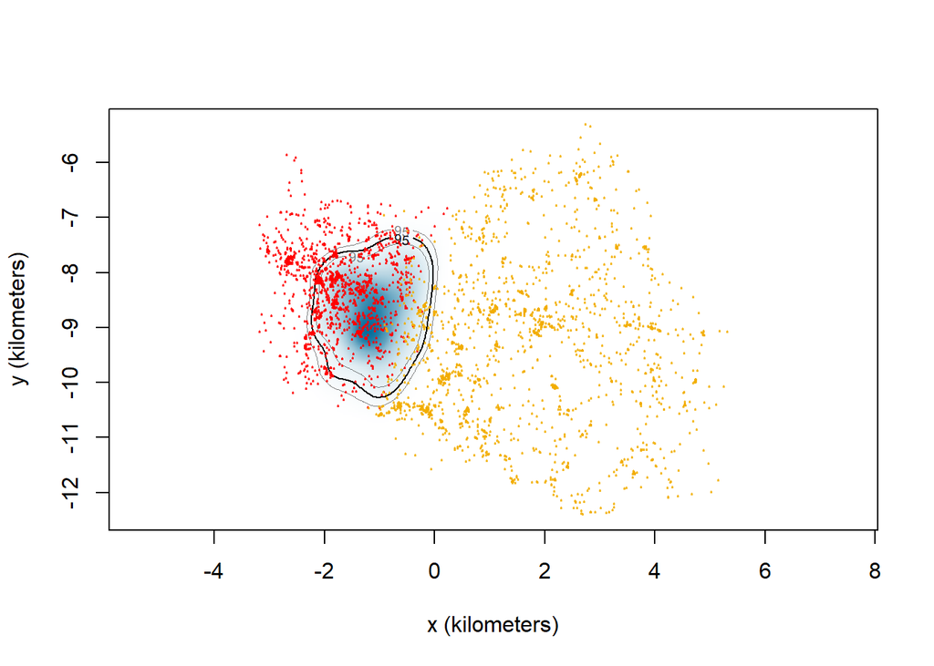

```r
plot(both.coyotes,
     col=c("#FF0000", "#F2AD00"),
     UD=CDE_coyotes,
     col.DF="#046C9A",
     col.grid = NA)
```

**Literature Cited**

C, J. M., Fleming, C. H., & Gurarie, E. (2016). ctmm: an r package for analyzing animal relocation data as a continuous-time stochastic process. Methods in Ecology and Evolution, 7(9), 1124–1132.

Codling, E. A., Plank, M. J., & Benhamou, S. (2008). Random walk models in biology. Journal of The Royal Society Interface, 5(25), 813–834. https://doi.org/10.1098/rsif.2008.0014 Nau, R. (2014, November 4). Notes on the random walk model - people.duke.edu. Notes on the random walk model. Retrieved 2021, from https://people.duke.edu/~rnau/Notes_on_the_random_walk_model--Robert_Nau.pdf